[figure not shown]

# Machine Learning Programming Workshop

## 2.2 Logistic Regression in Machine Learning

#### Prepared By: [Cheong Shiu Hong (FTFNCE)](https://www.linkedin.com/in/cheongshiuhong/)

## Contents

- 1) What is Logistic Regression?
- 2) Model with 1 Parameter (Gradient Only)
  - 2.1 Simulation
- 3) Model with 2 Parameters (Gradient & Y-Intercept)
  - 3.1 Simulation
  - 3.2 Derivatives of Cost Function
  - 3.3 Demonstration of Gradient Descent
- 4) Model with 3 Parameters (Multiple Regression)
  - 4.1 Simulation
  - 4.2 Derivatives of Cost Function
  - 4.3 Demonstration of Gradient Descent

```python
import numpy as np # Linear Algebra
import pandas as pd # Data Frames
import matplotlib.pyplot as plt # Visualization
import matplotlib.cm as cm # Color Mapping
from mpl_toolkits.mplot3d import axes3d # 3D Visualization
import ipywidgets as widgets # Interactivity
from IPython.display import display # Display Widgets
```

```python
%matplotlib notebook
```

# 1) What is Logistic Regression?

return to top

## Introduction to Logistic Regression:

#### Pretty much the same as Linear Regression, but we add Sigmoid at the end to scale it to between 0 and 1, a.k.a Probabilistic Output

#### - Used for Classification Tasks

#### - Change in Cost Function

### Denoted by: $ \sigma(x)$

[figure not shown]

### $\sigma(x) = \frac{1}{1 + e^{-x}}$

### $\sigma'(x) = \sigma(x) (1 - \sigma(x))$

```python
def sigmoid(x, grad=False):
    if grad:
        return sigmoid(x) * (1-sigmoid(x))
    return 1/(1+np.exp(-x))
```

```python
print('Sigmoid 6.5: {:.4f}'.format(sigmoid(6.5)))
print('Sigmoid 1.2: {:.4f}'.format(sigmoid(1.2)))
print('Sigmoid -8: {:.4f}'.format(sigmoid(-8)))
print('Sigmoid -4.5: {:.4f}'.format(sigmoid(-4.5)))
```

```
Sigmoid 6.5: 0.9985
Sigmoid 1.2: 0.7685
Sigmoid -8: 0.0003
Sigmoid -4.5: 0.0110
```

## Create Fake Dataset

```python
x = np.array([1., 1.9, 1.2, 4., 3.2, 2.4, 3.6, 4.6])
y = np.array([0, 0, 0, 1, 0, 1, 1, 1])
```

```python
x = np.array([1., 1.9, 1.2, 4., 3.2, 2.4, 3.6, 4.6])
x = x - x.mean()
y = np.array([0, 0, 0, 1, 0, 1, 1, 1])
```

```python
pd.DataFrame({'x':x,'y':y})
```

|  | x | y |
| --- | --- | --- |
| 0 | -1.7375 | 0 |
| 1 | -0.8375 | 0 |
| 2 | -1.5375 | 0 |
| 3 | 1.2625 | 1 |
| 4 | 0.4625 | 0 |
| 5 | -0.3375 | 1 |
| 6 | 0.8625 | 1 |
| 7 | 1.8625 | 1 |

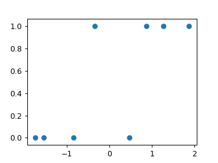

```python
fig = plt.figure(figsize=(4,3))
plt.scatter(x,y)
plt.show()
```

# 2) Model with 1 Parameter (Gradient Only)

$$\huge pred = \sigma(b + w . x) $$ $$$$

### Y-Intercept (b) as Zero, Therefore:

$$$$$$\huge pred = \sigma(w . x) $$

return to top

```python
def model(w, x):
    return sigmoid(w * x)
```

```python
def plot_model(title, init_weight=None):
    line_x = np.arange(-3, 8)
    if not init_weight:
        init_weight = np.random.randn(1)

    fig = plt.figure(figsize=(7,4))
    ax = fig.add_subplot(1,1,1)

    plt.suptitle(title, fontsize=15)
    plt.xlabel('X', fontsize=15)
    plt.ylabel('Y', fontsize=15)

#     plt.axis([-4, 9, -1, 2])
    ax.axhline(0, color='black')
    ax.axvline(0, color='black')
    ax.axhline(0.5, color='black', linewidth=0.5)

    ax.scatter(x, y, c='red')
    line, = ax.plot(line_x, model(init_weight, line_x), c='green')

    def update(weight=init_weight):
        line.set_ydata(model(weight, line_x))
        fig.canvas.draw()

    gradient = widgets.FloatText(value=init_weight, description='Gradient', step=0.1)
    display(gradient)
    widgets.interactive(update, weight=gradient)
```

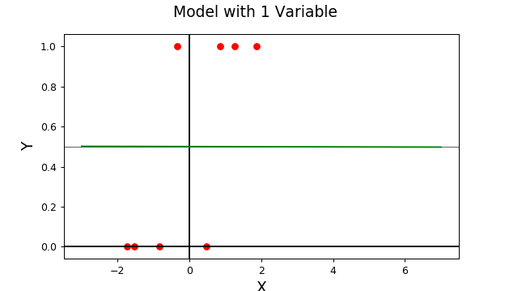

```python
plot_model('Model with 1 Variable')
```

## 2.1 Simulation for Visualization

return to top

```python
size = 50

w_sim = np.linspace(-10, 15, size)

w_matrix = w_sim.reshape(size, 1)
x_matrix = x.reshape(1, x.shape[0])
y_matrix = y.reshape(1, y.shape[0])

# Mean Squared Error as Cost Function
pred_sim = np.array([sigmoid(z) for z in w_matrix * x_matrix])
error_sim = (pred_sim - y_matrix)
cost_sim = np.sum(error_sim**2, 1)/len(y)

# Cross Entropy Loss as Cost Function
epsilon = 1e-8 # To Prevent -inf in log(pred)
cel_error = ((y_matrix * np.log(pred_sim + epsilon)) + ((1-y_matrix) * np.log(1-pred_sim + epsilon)))
cel_cost = -np.sum(cel_error, len(cel_error.shape)-1)/len(y)
```

```python
print('W Sim:\n', w_sim, '\n\nMean Squared Error Sim:\n', cost_sim, '\n\nCross Entropy Loss Sim', cel_cost)
```

```
W Sim:
 [-10.          -9.48979592  -8.97959184  -8.46938776  -7.95918367
  -7.44897959  -6.93877551  -6.42857143  -5.91836735  -5.40816327
  -4.89795918  -4.3877551   -3.87755102  -3.36734694  -2.85714286
  -2.34693878  -1.83673469  -1.32653061  -0.81632653  -0.30612245
   0.20408163   0.71428571   1.2244898    1.73469388   2.24489796
   2.75510204   3.26530612   3.7755102    4.28571429   4.79591837
   5.30612245   5.81632653   6.32653061   6.83673469   7.34693878
   7.85714286   8.36734694   8.87755102   9.3877551    9.89795918
  10.40816327  10.91836735  11.42857143  11.93877551  12.44897959
  12.95918367  13.46938776  13.97959184  14.48979592  15.        ]

Mean Squared Error Sim:
 [0.75004524 0.7500498  0.75004832 0.75003373 0.74999341 0.74990525
 0.74973112 0.74940593 0.74881952 0.74778616 0.74599372 0.74291782
 0.73767614 0.72877803 0.71369006 0.68809713 0.64481785 0.57324038
 0.46391338 0.32710187 0.20775584 0.14260362 0.12171093 0.12209105
 0.13087666 0.14268282 0.15519888 0.16735001 0.17862734 0.1888114
 0.19783977 0.20573706 0.2125751  0.21844919 0.22346363 0.22772278
 0.23132589 0.23436419 0.23691964 0.23906458 0.24086206 0.24236649
 0.24362443 0.24467554 0.24555336 0.24628621 0.24689791 0.24740844
 0.24783452 0.24819015]

Cross Entropy Loss Sim [9.98656458 9.54669928 9.07016821 8.5726584  8.06538902 7.55423114
 7.04185782 6.52947237 6.01769061 5.50693773 4.99763504 4.49031608
 3.98574556 3.48509897 2.9902836  2.50454754 2.03364178 1.587892
 1.18501176 0.85053599 0.60795248 0.45996346 0.3858157  0.35912859
 0.36046306 0.37824192 0.4059994  0.44010443 0.47844466 0.51973409
 0.56315234 0.60815278 0.6543568  0.70149329 0.7493626  0.79781433
 0.84673298 0.89602854 0.94563001 0.99548081 1.04553554 1.09575753
 1.14611701 1.19658971 1.24715581 1.29779905 1.34850608 1.3992659
 1.45006945 1.50090924]
```

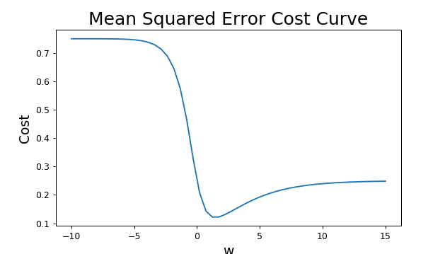

```python
fig = plt.figure(figsize=(7,4))
ax = fig.add_subplot(111)

plt.title('Mean Squared Error Cost Curve', fontsize=20)
ax.set_xlabel('w', fontsize=15)
ax.set_ylabel('Cost', fontsize=15)

ax.plot(w_sim, cost_sim)
plt.show()
```

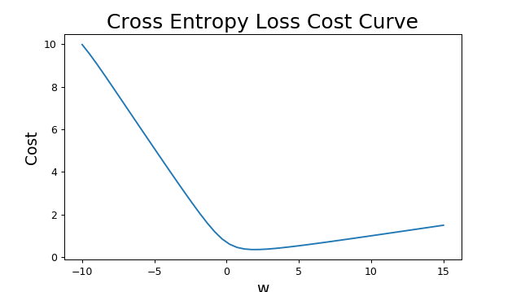

```python
fig = plt.figure(figsize=(7,4))
ax = fig.add_subplot(111)

plt.title('Cross Entropy Loss Cost Curve', fontsize=20)
ax.set_xlabel('w', fontsize=15)
ax.set_ylabel('Cost', fontsize=15)

ax.plot(w_sim, cel_cost)
plt.show()
```

```python
minimum_cost_index = np.argmin(cost_sim)
best_w = w_sim[minimum_cost_index]

print('Minimum Index:', minimum_cost_index, \
      '\nCost:', cost_sim[minimum_cost_index], \
      '\nGradient:', w_sim[minimum_cost_index])
```

```
Minimum Index: 22
Cost: 0.12171092629904746
Gradient: 1.2244897959183678
```

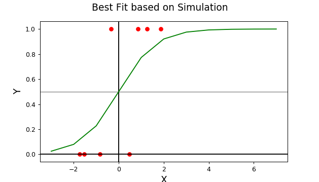

```python
plot_model('Best Fit based on Simulation', init_weight=best_w)
```

# 3) Model with 2 Parameters (Gradient and Y-Intercept)

$$\huge pred = \sigma(b + w . x) $$ $$$$

### Expressed as:

$$$$$$\huge pred = \sigma(\theta_0 + \theta_1 . x)$$

return to top

```python
def model(b, w, x):
    return sigmoid(b + w * x)
```

```python
def plot_model(title, init_weight=None, init_bias=None):
    line_x = np.arange(-3, 8)
    if not init_weight:
        init_weight = np.random.randn(1)
    if not init_bias:
        init_bias = np.random.randn(1)

    fig = plt.figure(figsize=(7,4))
    ax = fig.add_subplot(1,1,1)

    plt.suptitle(title, fontsize=15)
    plt.xlabel('X', fontsize=15)
    plt.ylabel('Y', fontsize=15)

#     plt.axis([-2, 7, -1, 2])
    ax.axhline(0, color='black')
    ax.axvline(0, color='black')
    ax.axhline(0.5, color='black', linewidth=0.5)

    ax.scatter(x, y, c='red')
    line, = ax.plot(line_x, model(init_bias, init_weight, line_x), c='green')

    def update(weight=init_weight, bias=init_bias):
        line.set_ydata(model(bias, weight, line_x))
        fig.canvas.draw()

    gradient = widgets.FloatText(value=init_weight, description='Gradient')
    bias = widgets.FloatText(value=init_bias, description='Y-Intercept')
    display(gradient)
    display(bias)
    widgets.interactive(update, weight=gradient, bias=bias)
```

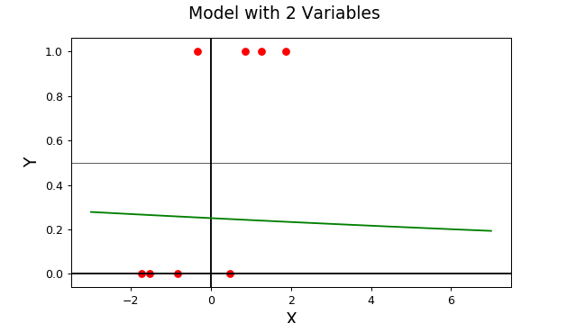

```python
plot_model('Model with 2 Variables')
```

## 3.1 Simulation for Visualization

### Create Simulation Data for Each Possible Point of $\theta_0$ and $\theta_1$

return to top

```python
size = 100

w_sim = np.linspace(-10, 20, size)
b_sim = np.linspace(-50, 50, size)
W, B = np.meshgrid(w_sim, b_sim)

w_matrix = w_sim.reshape(size, 1)
b_matrix = b_sim.reshape(1, size)
x_matrix = x.reshape(1, x.shape[0])
y_matrix = y.reshape(1, y.shape[0])

plot_w = np.repeat(w_sim, size)
plot_b = np.tile(b_sim, size)

# (Sw,1) x (1xN) --> (Sw,N) --reshape--> (Sw,N,1)
wx = np.dot(w_matrix, x_matrix).reshape(size, x.shape[0], 1)

# (Sw,N,1) + (1,Sb) --> (Sw,N,Sb) --tranpose--> (Sw,Sb,N)
pred_sim = sigmoid((wx + b_matrix).transpose(0, 2, 1))
```

### Using Mean Squared Error (MSE) as our Cost Function

```python
# ((Sw,Sb,N) - (1,N))^2 --> (Sw,Sb,N)
error_sim = pred_sim - y_matrix
squared_error_sim = error_sim**2

# Flatten (Sw,Sb) --> (Sw x Sb)
cost_sim_mse = np.sum(squared_error_sim, len(squared_error_sim.shape)-1)/len(y) # Sum (50, 50, 8) in Dim 2 --> (50, 50)
plot_cost = cost_sim_mse.reshape(-1) # Flatten (50,50) --> (2500,)
```

```python
pd.DataFrame({'Gradient': plot_w, 'Intercept': plot_b, 'Cost': plot_cost}).head(5)
```

|  | Gradient | Intercept | Cost |
| --- | --- | --- | --- |
| 0 | -10.0 | -50.000000 | 0.5 |
| 1 | -10.0 | -48.989899 | 0.5 |
| 2 | -10.0 | -47.979798 | 0.5 |
| 3 | -10.0 | -46.969697 | 0.5 |
| 4 | -10.0 | -45.959596 | 0.5 |

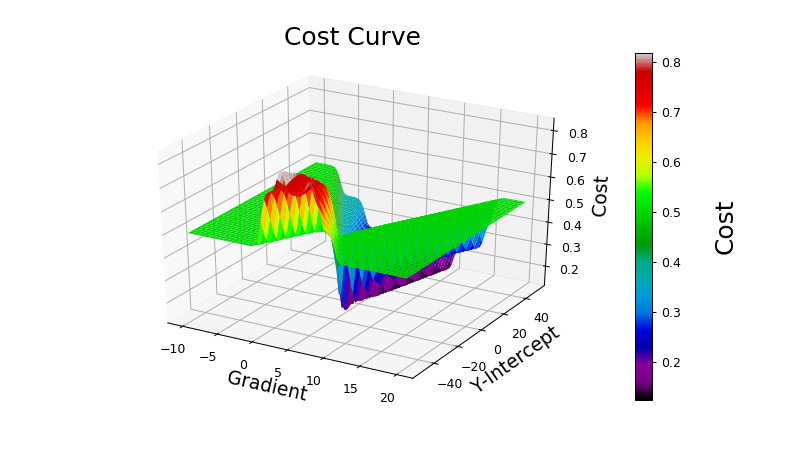

```python
# 3D Visualization
out = widgets.Output(layout={'border': '1px solid black'})
out.append_stdout('Using Mean Squared Error gives us a Non-Convex Cost Curve')
display(out)

fig = plt.figure(figsize=(9,5))
ax = fig.add_subplot(111, projection='3d')

plot = ax.plot_surface(W, B, cost_sim_mse, cmap=cm.nipy_spectral)

cbar=plt.colorbar(plot)
cbar.set_label('\nCost', fontsize=20)

plt.title('Cost Curve\n', fontsize=20)
ax.set_xlabel('Gradient', fontsize=15)
ax.set_ylabel('Y-Intercept', fontsize=15)
ax.set_zlabel(' Cost', fontsize=15)

plt.show()
```

```python
minimum_cost_index = np.argmin(plot_cost)
MSE_C = plot_cost[minimum_cost_index]
MSE_b = plot_b[minimum_cost_index]
MSE_w = plot_w[minimum_cost_index]

print('Minimum Index:', minimum_cost_index, \
      '\nCost:', MSE_C, \
      '\nY-Intercept:', MSE_b, \
      '\nGradient:', MSE_w)
```

```
Minimum Index: 9961
Cost: 0.12501159512648735
Y-Intercept: 11.61616161616162
Gradient: 20.0
```

### Using Cross Entropy Loss as our Cost Function

## $$Cost = - \frac{1}{n}\sum\limits_{i=1}^{n} y_{i} . \log{(pred_{i})} + (1-y_{i}) . \log{(1-pred_{i})}$$

### if y is 0:

### $y . \log{(pred)} = 0$

### $\therefore Cost = - \frac{1}{n}\sum\limits_{i=1}^{n} (1-y) . \log{(1-pred)}$

### if y is 1:

### $(1-y) . \log{(1-pred)} = 0$

### $\therefore Cost = - \frac{1}{n}\sum\limits_{i=1}^{n} y . \log{(pred)}$

```python
epsilon = 1e-8 # To Prevent -inf in log(pred)

# ((Sw,Sb,N) - (1,N))^2 --> (Sw,Sb,N)
error = ((y_matrix * np.log(pred_sim + epsilon)) + ((1-y_matrix) * np.log(1-pred_sim + epsilon)))

# Flatten (Sw,Sb) --> (Sw x Sb)
cost_sim_ce = -np.sum(error, len(error.shape)-1)/len(y) # Sum (50, 50, 8) in Dim 2 --> (50, 50)
plot_cost = cost_sim_ce.reshape(-1) # Flatten (50,50) --> (2500,)
```

#### Epsilon

```python
# We add Epsilon because log(0) = -inf
# Which will give us error in further calculations
np.log(0)
```

```
-inf
```

```python
pd.DataFrame({'Gradient': plot_w, 'Intercept': plot_b, 'Cost': plot_cost}).head(5)
```

|  | Gradient | Intercept | Cost |
| --- | --- | --- | --- |
| 0 | -10.0 | -50.000000 | 9.21034 |
| 1 | -10.0 | -48.989899 | 9.21034 |
| 2 | -10.0 | -47.979798 | 9.21034 |
| 3 | -10.0 | -46.969697 | 9.21034 |
| 4 | -10.0 | -45.959596 | 9.21034 |

```python
pd.DataFrame({'Gradient': plot_w, 'Intercept': plot_b, 'Cost': plot_cost}).tail(5)
```

|  | Gradient | Intercept | Cost |
| --- | --- | --- | --- |
| 9995 | 20.0 | 45.959596 | 7.902536 |
| 9996 | 20.0 | 46.969697 | 8.146718 |
| 9997 | 20.0 | 47.979798 | 8.378751 |
| 9998 | 20.0 | 48.989899 | 8.587394 |
| 9999 | 20.0 | 50.000000 | 8.763603 |

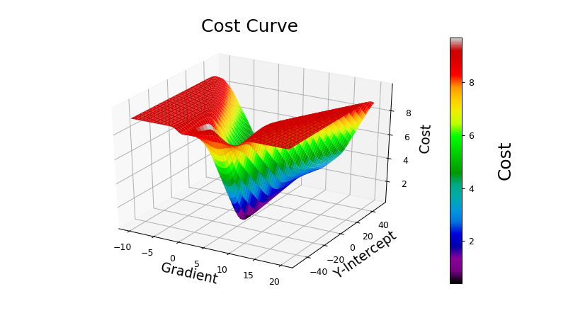

```python
# 3D Visualization
out = widgets.Output(layout={'border': '1px solid black'})
out.append_stdout('Using Cross Entropy Loss gives us a Convex Cost Curve')
display(out)

fig = plt.figure(figsize=(9,5))
ax = fig.add_subplot(111, projection='3d')

plot = ax.plot_surface(W, B, cost_sim_ce, cmap=cm.nipy_spectral)

cbar=plt.colorbar(plot)
cbar.set_label('\nCost', fontsize=20)

plt.title('Cost Curve\n', fontsize=20)
ax.set_xlabel('Gradient', fontsize=15)
ax.set_ylabel('Y-Intercept', fontsize=15)
ax.set_zlabel(' Cost', fontsize=15)


plt.show()
```

```python
minimum_cost_index = np.argmin(plot_cost)
CE_C = plot_cost[minimum_cost_index]
CE_b = plot_b[minimum_cost_index]
CE_w = plot_w[minimum_cost_index]

print('Minimum Index:', minimum_cost_index, \
      '\nCost:', plot_cost[minimum_cost_index], \
      '\nY-Intercept:', plot_b[minimum_cost_index], \
      '\nGradient:', plot_w[minimum_cost_index])
```

```
Minimum Index: 4049
Cost: 0.36859797123478977
Y-Intercept: -0.5050505050505052
Gradient: 2.121212121212121
```

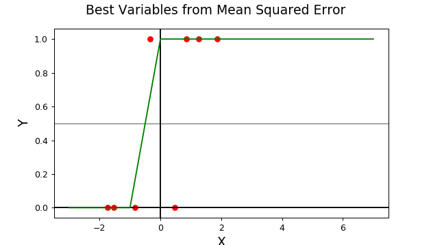

```python
plot_model('Best Variables from Mean Squared Error', init_weight=MSE_w, init_bias=MSE_b)
```

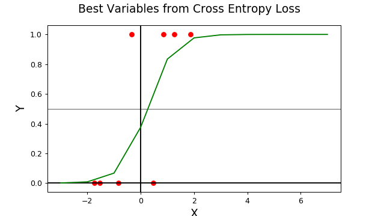

```python
plot_model('Best Variables from Cross Entropy Loss', init_weight=CE_w, init_bias=CE_b)
```

## 3.2 Derivatives of Cost Function

return to top

### $$ z = \theta_0 + \theta_1.x $$

### $$ pred = \sigma(z) $$

### $$ Cost = - \frac{1}{n}\sum\limits_{i=1}^{n} y . \log{(pred)} + (1-y) . \log{(1-pred)}$$

$$ \frac{dCost}{d\theta_0} = \frac{dCost}{dPred} \times \frac{dPred}{dZ} \times \frac{dZ}{d\theta_0} $$ $$$$ $$ \frac{dCost}{d\theta_0} = \frac{dCost}{dPred} \times \frac{dPred}{dZ} \times \frac{dZ}{d\theta_1} $$

#### x = Input Data (Independent Variable)

#### $\theta$ = Weights to be Optimized

#### y = True Values of Each Input Data (Dependent Variable)

### $ z = \theta_0 + \theta_1.x $

### $ pred = \sigma(Z) $

### $ Cost = - \frac{1}{n}\sum\limits_{i=1}^{n} y . \log{(pred)} + (1-y) . \log{(1-pred)}$

### Derivatives:

### Find $\frac{dCost}{d\theta_0} and \frac{dCost}{d\theta_1}$

### $\frac{dCost}{dPred} = \frac{pred - y}{pred(1 - pred)}$

### $\frac{dPred}{dZ} = \sigma(z) \times (1 - \sigma(z))$

#### or

### $\frac{dPred}{dZ} = pred \times (1 - pred)$

### Simplify:

### $\frac{dCost}{dZ} = \frac{pred - y}{pred(1 - pred)} \times pred(1 - pred)$

### $\frac{dCost}{dZ} = pred - y$

### $\frac{dZ}{d\theta_0} = 1$

### $\frac{dZ}{d\theta_1} = x$

### $\frac{dCost}{d\theta_0} = \frac{dCost}{dZ} \times \frac{dZ}{d\theta_0}$

### $\frac{dCost}{d\theta_0} = (pred - y) \times (1) $

### $\frac{dCost}{d\theta_0} = (\theta_0 + (\theta_1.x)) - y)$

### $\frac{dCost}{d\theta_1} = (pred - y) \times (x)$

### $\frac{dCost}{d\theta_1} = x(\theta_0 + (\theta_1.x)) - y)$

## 3.3 Demonstration of Gradient Descent

return to top

### Mean Squared Error

```python
def one_iteration(x, y, learning_rate=1e-1, first=False):
    global theta, prev_theta
    prev_theta = theta

    X = np.vstack([np.ones(y.shape[0]), x])

    # Model
    pred = sigmoid(np.dot(theta, X))

    # Calculations for Backpropagation

    error = pred - y
    cost = sum(error**2)/len(error)

    dcost_dtheta = np.array([sum(2 * Xi * error)/len(error) for Xi in X])
    theta = theta - (dcost_dtheta * learning_rate)

    if len(x.shape) == 1:
        data = "Cost: {}\nBias: {}\nWeight: {}\nGradient of Cost Curve to Bias: {}\
            \nGradient of Cost Curve to Weight: {}\n".format(cost, theta[0], theta[1], dcost_dtheta[0], dcost_dtheta[1])
    elif len(x.shape) == 2:
        data = "Cost: {}\nBias: {}\nWeight 1: {}\nWeight 2: {}\nGradient of Cost Curve to Bias: {}\
            \nGradient of Cost Curve to Weight 1: {}\nGradient of Cost Curve to Weight 2: {}\n"\
            .format(cost, theta[0], theta[1], theta[2], dcost_dtheta[0], dcost_dtheta[1], dcost_dtheta[2])

    return cost, dcost_dtheta, data
```

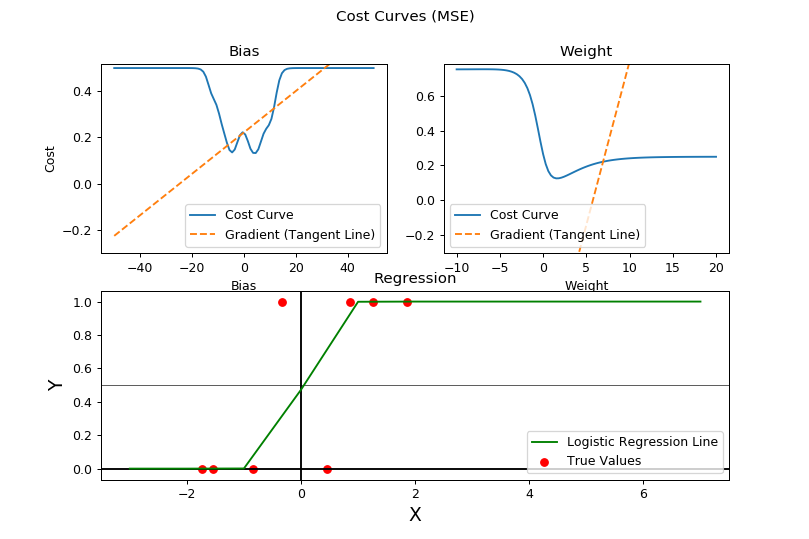

```python
def find_nearest(array, value):
    idx = (np.abs(array - value)).argmin()
    return idx

def update(iterations, nested=0):
    # Run Iteration
    if nested:
        for i in range(nested):
            cost, dcost_dtheta, data = one_iteration(x, y)
    else:
        cost, dcost_dtheta, data = one_iteration(x, y)
    # Replot Cost Curves
    b_nearest = find_nearest(b_sim, prev_theta[0])
    w_nearest = find_nearest(w_sim, prev_theta[1])
    curve_b.set_ydata(cost_sim_mse[w_nearest])
    curve_w.set_ydata(cost_sim_mse[:, b_nearest])
    # Replot Tangents
    intercept_b = cost - (prev_theta[0] * dcost_dtheta[0])
    intercept_w = cost - (prev_theta[1] * dcost_dtheta[1])
    tangent_b.set_ydata((dcost_dtheta[0]*b_sim)+intercept_b)
    tangent_w.set_ydata((dcost_dtheta[1]*w_sim)+intercept_w)
    # Replot Regression Line
    line.set_ydata(model(theta[0], theta[1], line_x))
    # Clear and Redraw
    out.clear_output()
    fig.canvas.draw()
    out.append_stdout(data)

def update_ten(iterations):
    if visualize.value:
        for i in range(10):
            update(1)
    else:
        update(1, nested=10)

def update_hundred(iterations):
    if visualize.value:
        for i in range(100):
            update(1)
    else:
        update(1, nested=100)

##### Widgets #####
out = widgets.Output(layout={'border': '1px solid black'})
button_one = widgets.Button(description="1 Iteration")
button_one.on_click(update)
button_ten = widgets.Button(description="10 Iterations")
button_ten.on_click(update_ten)
button_hundred = widgets.Button(description="!!!100 Iterations!!!")
button_hundred.on_click(update_hundred)
visualize = widgets.Checkbox(value=False, description='Visualize Changes', disabled=False)
hbox = widgets.HBox([button_one, button_ten, button_hundred, visualize])

# Initialize Random Weight & Bias
theta = np.random.uniform(-8,8, size=2)
# theta = np.array([-5, 5])

# Run First Iteration
cost, dcost_dtheta, data = one_iteration(x, y)

b_nearest = find_nearest(b_sim, theta[0])
w_nearest = find_nearest(w_sim, theta[1])

############################
### Visualize Cost Curve ###
############################
fig = plt.figure(figsize=(9,6))
ax = fig.add_subplot(111)
plt.suptitle('Cost Curves (MSE)')

##### Bias Subplot #####
plt.subplot(2,2,1)
# plt.axis([-10.5,10.5,-500,2000])
plt.title('Bias')
plt.xlabel('Bias')
plt.ylabel('Cost')
# Cost Curve
curve_b, = plt.plot(b_sim, cost_sim_mse[w_nearest], label='Cost Curve')
x1, x2, y1, y2 = plt.axis()
plt.axis([x1,x2,-0.3,y2])
# Tangent
intercept_b = cost - (prev_theta[0] * dcost_dtheta[0])
tangent_b, = plt.plot(b_sim, (dcost_dtheta[0]*b_sim)+intercept_b, label='Gradient (Tangent Line)', linestyle='--')
plt.legend();

##### Weight Subplot #####
plt.subplot(2,2,2)
plt.title('Weight')
plt.xlabel('Weight')
# Cost Curve
curve_w, = plt.plot(w_sim, cost_sim_mse[:, b_nearest], label='Cost Curve')
x1, x2, y1, y2 = plt.axis()
plt.axis([x1,x2,-0.3,y2])
# Tangent
intercept_w = cost - (prev_theta[1] * dcost_dtheta[1])
tangent_w, = plt.plot(w_sim, (dcost_dtheta[1]*w_sim)+intercept_w, label='Gradient (Tangent Line)', linestyle='--')
plt.legend();

##### Regression Line Subplot #####
plt.subplot(2,2,(3,4))
# plt.axis([-1,8,-3,10])
plt.title('Regression')
plt.xlabel('X', fontsize=15)
plt.ylabel('Y', fontsize=15)
plt.axhline(0, color='black')
plt.axvline(0, color='black')
plt.axhline(0.5, color='black', linewidth=0.5)
line_x = np.arange(-3, 8)
##### Data Points #####
plt.scatter(x, y, label='True Values', c='red')
##### Regression #####
line, = plt.plot(line_x, model(theta[0], theta[1], line_x), label='Logistic Regression Line', c='green')
plt.legend();

update(1)
display(hbox)
out
```

### Cross Entropy Loss

```python
def one_iteration(x, y, learning_rate=1e-1, first=False):
    global theta, prev_theta
    prev_theta = theta

    X = np.vstack([np.ones(y.shape[0]), x])

    # Model
    pred = sigmoid(np.dot(theta, X))

    # Calculations for Backpropagation

    error = ((y * np.log(pred + epsilon)) + ((1-y) * np.log(1-pred + epsilon)))
    cost = - np.sum(error, len(error.shape)-1)/len(error)

    dcost_dtheta = np.array([sum(Xi * (pred-y))/len(error) for Xi in X])
    theta = theta - (dcost_dtheta * learning_rate)

    if len(x.shape) == 1:
        data = "Cost: {}\nBias: {}\nWeight: {}\nGradient of Cost Curve to Bias: {}\
            \nGradient of Cost Curve to Weight: {}\n".format(cost, theta[0], theta[1], dcost_dtheta[0], dcost_dtheta[1])
    elif len(x.shape) == 2:
        data = "Cost: {}\nBias: {}\nWeight 1: {}\nWeight 2: {}\nGradient of Cost Curve to Bias: {}\
            \nGradient of Cost Curve to Weight 1: {}\nGradient of Cost Curve to Weight 2: {}\n"\
            .format(cost, theta[0], theta[1], theta[2], dcost_dtheta[0], dcost_dtheta[1], dcost_dtheta[2])

    return cost, dcost_dtheta, data
```

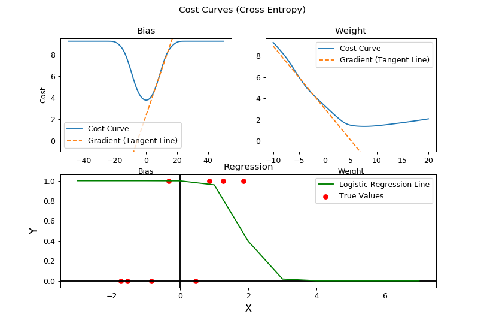

```python
def find_nearest(array, value):
    idx = (np.abs(array - value)).argmin()
    return idx

def update(iterations, nested=0):
    # Run Iteration
    if nested:
        for i in range(nested):
            cost, dcost_dtheta, data = one_iteration(x, y)
    else:
        cost, dcost_dtheta, data = one_iteration(x, y)
    # Replot Cost Curves
    b_nearest = find_nearest(b_sim, prev_theta[0])
    w_nearest = find_nearest(w_sim, prev_theta[1])
    curve_b.set_ydata(cost_sim_ce[w_nearest])
    curve_w.set_ydata(cost_sim_ce[:, b_nearest])
    # Replot Tangents
    intercept_b = cost - (prev_theta[0] * dcost_dtheta[0])
    intercept_w = cost - (prev_theta[1] * dcost_dtheta[1])
    tangent_b.set_ydata((dcost_dtheta[0]*b_sim)+intercept_b)
    tangent_w.set_ydata((dcost_dtheta[1]*w_sim)+intercept_w)
    # Replot Regression Line
    line.set_ydata(model(theta[0], theta[1], line_x))
    # Clear and Redraw
    out.clear_output()
    fig.canvas.draw()
    out.append_stdout(data)

def update_ten(iterations):
    if visualize.value:
        for i in range(10):
            update(1)
    else:
        update(1, nested=10)

def update_hundred(iterations):
    if visualize.value:
        for i in range(100):
            update(1)
    else:
        update(1, nested=100)

##### Widgets #####
out = widgets.Output(layout={'border': '1px solid black'})
button_one = widgets.Button(description="1 Iteration")
button_one.on_click(update)
button_ten = widgets.Button(description="10 Iterations")
button_ten.on_click(update_ten)
button_hundred = widgets.Button(description="!!!100 Iterations!!!")
button_hundred.on_click(update_hundred)
visualize = widgets.Checkbox(value=False, description='Visualize Changes', disabled=False)
hbox = widgets.HBox([button_one, button_ten, button_hundred, visualize])

# Initialize Random Weight & Bias
theta = np.random.uniform(-8,8, size=2)
# theta = np.array([-5, 5])

# Run First Iteration
cost, dcost_dtheta, data = one_iteration(x, y)

b_nearest = find_nearest(b_sim, theta[0])
w_nearest = find_nearest(w_sim, theta[1])

############################
### Visualize Cost Curve ###
############################
fig = plt.figure(figsize=(9,6))
ax = fig.add_subplot(111)
plt.suptitle('Cost Curves (Cross Entropy)')

##### Bias Subplot #####
plt.subplot(2,2,1)
# plt.axis([-10.5,10.5,-500,2000])
plt.title('Bias')
plt.xlabel('Bias')
plt.ylabel('Cost')
# Cost Curve
curve_b, = plt.plot(b_sim, cost_sim_ce[w_nearest], label='Cost Curve')
x1, x2, y1, y2 = plt.axis()
plt.axis([x1,x2,-1,y2])
# Tangent
intercept_b = cost - (prev_theta[0] * dcost_dtheta[0])
tangent_b, = plt.plot(b_sim, (dcost_dtheta[0]*b_sim)+intercept_b, label='Gradient (Tangent Line)', linestyle='--')
plt.legend();

##### Weight Subplot #####
plt.subplot(2,2,2)
plt.title('Weight')
plt.xlabel('Weight')
# Cost Curve
curve_w, = plt.plot(w_sim, cost_sim_ce[:, b_nearest], label='Cost Curve')
x1, x2, y1, y2 = plt.axis()
plt.axis([x1,x2,-1,y2])
# Tangent
intercept_w = cost - (prev_theta[1] * dcost_dtheta[1])
tangent_w, = plt.plot(w_sim, (dcost_dtheta[1]*w_sim)+intercept_w, label='Gradient (Tangent Line)', linestyle='--')
plt.legend();

##### Regression Line Subplot #####
plt.subplot(2,2,(3,4))
# plt.axis([-1,8,-3,10])
plt.title('Regression')
plt.xlabel('X', fontsize=15)
plt.ylabel('Y', fontsize=15)
plt.axhline(0, color='black')
plt.axvline(0, color='black')
plt.axhline(0.5, color='black', linewidth=0.5)
line_x = np.arange(-3, 8)
##### Data Points #####
plt.scatter(x, y, label='True Values', c='red')
##### Regression #####
line, = plt.plot(line_x, model(theta[0], theta[1], line_x), label='Logistic Regression Line', c='green')
plt.legend();

update(1)
display(hbox)
out
```

# 4) Model with Three Variables (Multiple Regression)

$$\huge pred = \sigma(b + w_1.x_1 + w_2.x_2) $$ $$$$$$\huge pred = \sigma(\theta_0 + \theta_1 . x_1 + \theta_2 . x_2) $$

return to top

```python
def model(b, w1, x1, w2, x2):
    return sigmoid(b + (w1 * x1) + (w2 * x2))
```

### New Fake Data for Multiple Logistic Regression

```python
x1 = np.array([1., 2.8, 1.2, 2.7, 3.2, 2.4, 3.6, 4.6])
x1 = (x1 - x1.mean()) * 3
x2 = np.array([8.1, 6.7, 6.5, 3.2, 5.1, 4.9, 3.9, 4.1])
x2 = (x2 - x2.mean()) * 3
y = np.array([0, 0, 0, 1, 1, 0, 1, 1 ])

X = np.vstack([x1, x2])
```

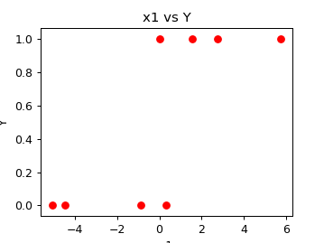

```python
fig = plt.figure(figsize=(4,3))
plt.title('x1 vs Y'); plt.xlabel('x1'); plt.ylabel('Y')
plt.scatter(x1, y, c='r')
plt.show()
```

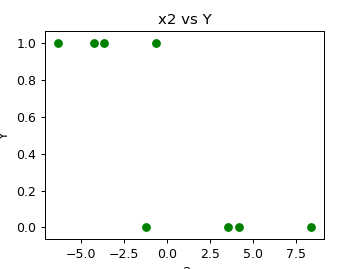

```python
fig = plt.figure(figsize=(4,3))
plt.title('x2 vs Y'); plt.xlabel('x2'); plt.ylabel('Y')
plt.scatter(x2, y, c='g')
plt.show()
```

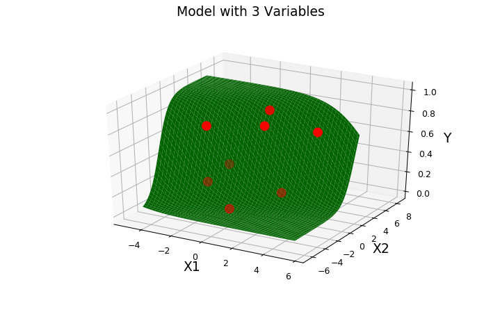

```python
size = 100

line_x1 = np.linspace(-5,5,size)
line_x2 = np.linspace(-5,5,size)
lx1, lx2 = np.meshgrid(line_x1, line_x2)

init = np.random.randn(3)

fig = plt.figure(figsize=(8,5))
ax = fig.add_subplot(111, projection='3d')

ax.scatter(x1, x2, y, s=100, c='r')
z = model(init[0], init[1], lx1, init[2], lx2)
line = ax.plot_surface(lx1, lx2, z, color='green')

plt.suptitle('Model with 3 Variables', fontsize=15)

plt.axes([0, 10, 0, 10])

def update(intercept=init[0], weight_1=init[1], weight_2=init[2]):
    global ax, line
    ax.clear()
    ax.set_xlabel('X1', fontsize=15)
    ax.set_ylabel('X2', fontsize=15)
    ax.set_zlabel('Y', fontsize=15)
    ax.scatter(x1, x2, y, s=100, c='r')
    z = model(intercept, weight_1, lx1, weight_2, lx2)
    line = ax.plot_surface(lx1, lx2, z, color='green')
    fig.canvas.draw()

intercept = widgets.FloatText(value=init[0], description='Y-Intercept', step=0.1)
gradient_1 = widgets.FloatText(value=init[1], description='Gradient 1', step=0.1)
gradient_2 = widgets.FloatText(value=init[2], description='Gradient 2', step=0.1)

widgets.interactive(update, intercept=intercept, weight_1=gradient_1, weight_2=gradient_2)
```

## 4.1 Simulation for Visualization

### Create Simulation Data for Each Possible Point of $\theta_0$, $\theta_1$, and $\theta_2$

return to top

```python
size = 100

w1_raw = np.linspace(-15,15,size)
w2_raw = np.linspace(-15,15,size)

w1_sim = np.repeat(w1_raw, size)
w2_sim = np.tile(w2_raw, size)
b_sim = np.linspace(-20, 20, size)

w1_matrix = w1_sim.reshape(size*size, 1)
w2_matrix = w2_sim.reshape(size*size, 1)
b_matrix = b_sim.reshape(1, size)
x1_matrix = x1.reshape(1, x1.shape[0])
x2_matrix = x2.reshape(1, x2.shape[0])
y_matrix = y.reshape(1, y.shape[0])

plot_w1 = np.repeat(w1_raw, size*size)
plot_w2 = np.tile(np.repeat(w2_raw, size), size)
plot_b = np.tile(b_sim, size*size)

# (Sw2xSw1,1) x (1xN) --> (Sw2xSw1,N) --reshape--> (Sw1xSw2,N,1)
w_matrix = np.hstack([w1_matrix, w2_matrix])
x_matrix = np.vstack([x1_matrix, x2_matrix])
wx = np.dot(w_matrix, x_matrix).reshape(size*size, x1.shape[0], 1)

# (Sw2xSw1,N,1) + (1,Sb) --> (Sw2xSw1,N,Sb) --tranpose--> (Sw2xSw1,Sb,N)
pred_sim = sigmoid((wx + b_matrix).transpose(0, 2, 1))
```

```python
# ((Sw1xSw2,Sb,N) - (1,N))^2 --> (Sw1xSw2,Sb,N)
error_sim = pred_sim - y_matrix
squared_error_sim = error_sim**2
print(squared_error_sim.shape)
# Sum (Sw1xSw2,Sb,N) in Dim 2 --> (Sw1xSw2,Sb)
cost_sim_mse = np.sum(squared_error_sim, len(squared_error_sim.shape)-1)/len(y)

# Flatten (Sw1xSw2,Sb) --> (Sw1xSw2 x Sb)
plot_cost = cost_sim_mse.reshape(-1) # Flatten (50,50) --> (2500,)
```

```
(10000, 100, 8)
```

```python
pd.DataFrame({'Gradient_1': plot_w1, 'Gradient_2': plot_w2, 'Intercept': plot_b, 'Cost': plot_cost}).head(5)
```

|  | Gradient_1 | Gradient_2 | Intercept | Cost |
| --- | --- | --- | --- | --- |
| 0 | -15.0 | -15.0 | -20.000000 | 0.375717 |
| 1 | -15.0 | -15.0 | -19.595960 | 0.375336 |
| 2 | -15.0 | -15.0 | -19.191919 | 0.375156 |
| 3 | -15.0 | -15.0 | -18.787879 | 0.375073 |
| 4 | -15.0 | -15.0 | -18.383838 | 0.375039 |

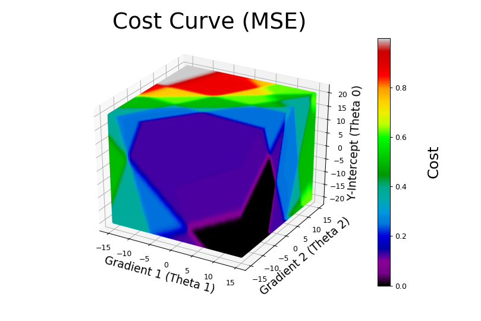

```python
# 3D Visualization
fig = plt.figure(figsize=(9,6))
ax = fig.add_subplot(111, projection='3d')

plot = ax.scatter(plot_w1, plot_w2, plot_b, c=plot_cost, cmap='nipy_spectral')

cbar=plt.colorbar(plot)
cbar.set_label('\nCost', fontsize=20)

plt.title('Cost Curve (MSE)\n', fontsize=30)
ax.set_xlabel('Gradient 1 (Theta 1)', fontsize=15)
ax.set_ylabel('Gradient 2 (Theta 2)', fontsize=15)
ax.set_zlabel('Y-Intercept (Theta 0)', fontsize=15)

plt.show()
```

```python
minimum_cost_index = np.argmin(plot_cost)
print('Minimum Index:', minimum_cost_index, \
      '\nCost:', plot_cost[minimum_cost_index], \
      '\nY-Intercept:', plot_b[minimum_cost_index], \
      '\nGradient 1:', plot_w1[minimum_cost_index], \
      '\nGradient 2:', plot_w2[minimum_cost_index])
```

```
Minimum Index: 993628
Cost: 7.792144492678969e-16
Y-Intercept: -8.686868686868687
Gradient 1: 15.0
Gradient 2: -4.09090909090909
```

### Cross Entropy Loss

```python
epsilon = 1e-8 # To Prevent -inf in log(pred)

# ((Sw,Sb,N) - (1,N))^2 --> (Sw,Sb,N)
error = ((y_matrix * np.log(pred_sim + epsilon)) + ((1-y_matrix) * np.log(1-pred_sim + epsilon)))

# Flatten (Sw,Sb) --> (Sw x Sb)
cost_sim_ce = -np.sum(error, len(error.shape)-1)/len(y) # Sum (50, 50, 8) in Dim 2 --> (50, 50)
plot_cost = cost_sim_ce.reshape(-1) # Flatten (50,50) --> (2500,)
```

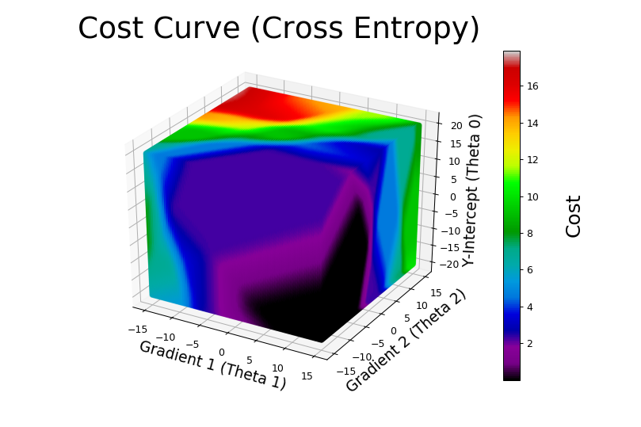

```python
# 3D Visualization
fig = plt.figure(figsize=(9,6))
ax = fig.add_subplot(111, projection='3d')

plot = ax.scatter(plot_w1, plot_w2, plot_b, c=plot_cost, cmap='nipy_spectral')

cbar=plt.colorbar(plot)
cbar.set_label('\nCost', fontsize=20)

plt.title('Cost Curve (Cross Entropy)\n', fontsize=30)
ax.set_xlabel('Gradient 1 (Theta 1)', fontsize=15)
ax.set_ylabel('Gradient 2 (Theta 2)', fontsize=15)
ax.set_zlabel('Y-Intercept (Theta 0)', fontsize=15)

plt.show()
```

```python
minimum_cost_index = np.argmin(plot_cost)
print('Minimum Index:', minimum_cost_index, \
      '\nCost:', plot_cost[minimum_cost_index], \
      '\nY-Intercept:', plot_b[minimum_cost_index], \
      '\nGradient 1:', plot_w1[minimum_cost_index], \
      '\nGradient 2:', plot_w2[minimum_cost_index])
```

```
Minimum Index: 993527
Cost: 4.820846148008532e-09
Y-Intercept: -9.090909090909092
Gradient 1: 15.0
Gradient 2: -4.3939393939393945
```

## 4.2 Derivatives of Cost Function

return to top

### $$ Pred = \theta_0 + \theta_1.x_1 + \theta_2.x_2 $$

### $$ Error = Pred - y $$

### $$ Cost = Error^2 $$

$$ \frac{Cost}{d\theta_0} = \frac{dCost}{dError} \times \frac{dError}{dPred} \times \frac{dPred}{d\theta_0} $$ $$$$ $$ \frac{dCost}{d\theta_1} = \frac{dCost}{dError} \times \frac{dError}{dPred} \times \frac{dPred}{d\theta_1} $$ $$$$ $$ \frac{dCost}{d\theta_2} = \frac{dCost}{dError} \times \frac{dError}{dPred} \times \frac{dPred}{d\theta_2} $$

#### x = Input Data (Independent Variable)

#### w = Weights to be Optimized

#### y = True Values of Each Input Data (Dependent Variable)

### $pred = \theta_0 + (\theta_1 . x_1) + (\theta_2 . x2)$

### $error = pred - y$

### $cost = error^2$

### Derivatives:

### Find $\frac{dCost}{d\theta_0}, \frac{dCost}{d\theta_1}, and \frac{dCost}{d\theta_2}$

### Recap: $\frac{dCost}{d\theta_0} = 2 \times (\theta_0 + (\theta_1.x_1) + (\theta_2.x_2) - y)$

### Recap: $\frac{dCost}{d\theta_1} = 2x_1 \times (\theta_0 + (\theta_1.x_1) + (\theta_2.x_2) - y)$

### $\frac{dCost}{dError} = 2 \times error$

### $\frac{dError}{dPred} = 1$

### $\frac{dPred}{d\theta_2} = x_2$

### $\frac{dCost}{d\theta_2} = \frac{dCost}{dError} \times \frac{dError}{dPred} \times \frac{dPred}{d\theta_2}$

### $\frac{dCost}{d\theta_2} = (2 \times error) \times (1) \times (x_2)$

### $\frac{dCost}{d\theta_2} = 2x_2 \times error$

### $\frac{dCost}{d\theta_2} = 2x_2 \times (pred - y)$

### $\frac{dCost}{d\theta_2} = 2x_2 \times (\theta_0 + (\theta_1.x_1) + (\theta_2.x_2) - y)$

### Therefore:

### $\frac{dCost}{d\theta_0} = 2 \times (\theta_0 + (\theta_1.x_1) + (\theta_2.x_2) - y)$

### $\frac{dCost}{d\theta_1} = 2x_1 \times (\theta_0 + (\theta_1.x_1) + (\theta_2.x_2) - y)$

### $\frac{dCost}{d\theta_2} = 2x_2 \times (\theta_0 + (\theta_1.x_1) + (\theta_2.x_2) - y)$

## 4.3) Demonstration of Gradient Descent

return to top

### Mean Squared Error

```python
def one_iteration(x, y, learning_rate=1e-1, first=False):
    global theta, prev_theta
    prev_theta = theta

    X = np.vstack([np.ones(y.shape[0]), x])

    # Model
    pred = sigmoid(np.dot(theta, X))

    # Calculations for Backpropagation
    error = pred - y
    cost = sum(error**2)/len(error)

    dcost_dtheta = np.array([sum(2 * Xi * error)/len(error) for Xi in X])
    theta = theta - (dcost_dtheta * learning_rate)

    if len(x.shape) == 1:
        data = "Cost: {}\nBias: {}\nWeight: {}\nGradient of Cost Curve to Bias: {}\
            \nGradient of Cost Curve to Weight: {}\n".format(cost, theta[0], theta[1], dcost_dtheta[0], dcost_dtheta[1])
    elif len(x.shape) == 2:
        data = "Cost: {}\nBias: {}\nWeight 1: {}\nWeight 2: {}\nGradient of Cost Curve to Bias: {}\
            \nGradient of Cost Curve to Weight 1: {}\nGradient of Cost Curve to Weight 2: {}\n"\
            .format(cost, theta[0], theta[1], theta[2], dcost_dtheta[0], dcost_dtheta[1], dcost_dtheta[2])

    return cost, dcost_dtheta, data
```

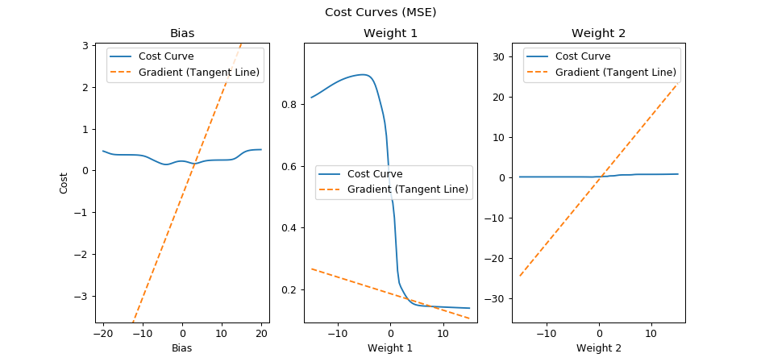

```python
def find_nearest(array, value):
    idx = (np.abs(array - value)).argmin()
    return idx

def match(array, value):
    cond = array == value
    return np.where(cond)[0]

def match_2(array1, array2, value1, value2):
    cond1 = array1 == value1
    cond2 = array2 == value2
    a = np.where(cond1)[0]
    b = np.where(cond2)[0]
    return a[np.where(np.in1d(a, b))][0]

def update(iterations, nested=0):
    # Run Iteration
    if nested:
        for i in range(nested):
            cost, dcost_dtheta, data = one_iteration(X, y)
    else:
        cost, dcost_dtheta, data = one_iteration(X, y)
    # Replot Cost Curves
    b_nearest = find_nearest(b_sim, prev_theta[0])
    w1_nearest = find_nearest(w1_raw, prev_theta[1])
    w2_nearest = find_nearest(w2_raw, prev_theta[2])
    curve_b.set_ydata(cost_sim_mse[match_2(w1_sim, w2_sim, w1_raw[w1_nearest], w2_raw[w2_nearest])])
    curve_w1.set_ydata(cost_sim_mse[match(w2_sim, w2_raw[w2_nearest]), b_nearest])
    curve_w2.set_ydata(cost_sim_mse[match(w1_sim, w1_raw[w1_nearest]), b_nearest])
    # Replot Tangents
    intercept_b = cost - (prev_theta[0] * dcost_dtheta[0])
    intercept_w1 = cost - (prev_theta[1] * dcost_dtheta[1])
    intercept_w2 = cost - (prev_theta[2] * dcost_dtheta[2])
    tangent_b.set_ydata((dcost_dtheta[0]*b_sim)+intercept_b)
    tangent_w1.set_ydata((dcost_dtheta[1]*w1_raw)+intercept_w1)
    tangent_w2.set_ydata((dcost_dtheta[2]*w2_raw)+intercept_w2)
    # Clear and Redraw
    out.clear_output()
    out.append_stdout(data)
    fig.canvas.draw()

def update_ten(iterations):
    if visualize.value:
        for i in range(10):
            update(1)
    else:
        update(1, nested=10)

def update_hundred(iterations):
    if visualize.value:
        for i in range(100):
            update(1)
    else:
        update(1, nested=100)

def update_thousand(iterations):
    if visualize.value:
        print('Not Allowed, Unselect Visualize to Proceed.')
    else:
        update(1, nested=1000)

##### Widgets #####
out = widgets.Output(layout={'border': '1px solid black'})
button_one = widgets.Button(description="1 Iteration")
button_one.on_click(update)
button_ten = widgets.Button(description="10 Iterations")
button_ten.on_click(update_ten)
button_hundred = widgets.Button(description="!!!100 Iterations!!!")
button_hundred.on_click(update_hundred)
button_thousand = widgets.Button(description="!!!Warning - 1000!!!")
button_thousand.on_click(update_thousand)
visualize = widgets.Checkbox(value=False, description='Visualize Changes', disabled=False)
hbox = widgets.HBox([button_one, button_ten, button_hundred, button_thousand, visualize])

# Initialize Random Weights & Bias
theta = np.random.uniform(-5,5,size=3)

# Run First Iteration
cost, dcost_dtheta, data = one_iteration(X, y)

b_nearest = find_nearest(b_sim, prev_theta[0])
w1_nearest = find_nearest(w1_raw, prev_theta[1])
w2_nearest = find_nearest(w2_raw, prev_theta[2])

############################
### Visualize Cost Curve ###
############################
fig = plt.figure(figsize=(10.5,5))
ax = fig.add_subplot(111)
plt.suptitle('Cost Curves (MSE)')

##### Bias Subplot #####
plt.subplot(1,3,1)
plt.title('Bias')
plt.xlabel('Bias')
plt.ylabel('Cost')
# Cost Curve
curve_b, = plt.plot(b_sim, cost_sim_mse[match_2(w1_sim, w2_sim, w1_raw[w1_nearest], w2_raw[w2_nearest])], label='Cost Curve')
d1,d2,d3,d4 = plt.axis()
# plt.axis([d1,d2,-1,10])
# Tangent
intercept_b = cost - (prev_theta[0] * dcost_dtheta[0])
tangent_b, = plt.plot(b_sim, (dcost_dtheta[0]*b_sim)+intercept_b, label='Gradient (Tangent Line)', linestyle='--')
plt.legend();

##### Weight 1 Subplot #####
plt.subplot(1,3,2)
# plt.axis([-30.5,30.5,-1000,1000])
plt.title('Weight 1')
plt.xlabel('Weight 1')
# Cost Curve
curve_w1, = plt.plot(w1_raw, cost_sim_mse[match(w2_sim, w2_raw[w2_nearest]), b_nearest], label='Cost Curve')
d1,d2,d3,d4 = plt.axis()
# plt.axis([d1,d2,-1,12])
# Tangent
intercept_w1 = cost - (prev_theta[1] * dcost_dtheta[1])
tangent_w1, = plt.plot(w1_raw, (dcost_dtheta[1]*w1_raw)+intercept_w1, label='Gradient (Tangent Line)', linestyle='--')
plt.legend();

##### Weight 2 Subplot #####
plt.subplot(1,3,3)
plt.title('Weight 2')
plt.xlabel('Weight 2')
# Cost Curve
curve_w2, = plt.plot(w2_raw, cost_sim_mse[match(w1_sim, w1_raw[w1_nearest]), b_nearest], label='Cost Curve')
d1,d2,d3,d4 = plt.axis()
# plt.axis([d1,d2,-1,12])
# Tangent
intercept_w2 = cost - (prev_theta[2] * dcost_dtheta[2])
tangent_w2, = plt.plot(w2_raw, (dcost_dtheta[2]*w2_raw)+intercept_w2, label='Gradient (Tangent Line)', linestyle='--')
plt.legend();

update(1)
display(hbox)
out
```

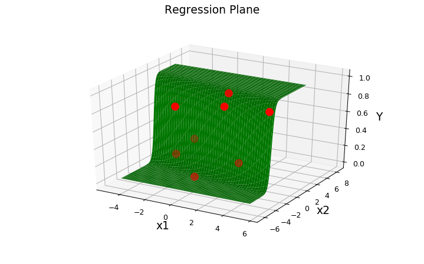

```python
def update(iterations, nested=1):
    for _ in range(nested):
        cost, dcost_dtheta, data = one_iteration(X, y)
    ax.clear()
    ax.set_xlabel('x1', fontsize=15)
    ax.set_ylabel('x2', fontsize=15)
    ax.set_zlabel('Y', fontsize=15)
    ax.scatter(x1, x2, y, s=100, c='r')
    z = model(theta[0], theta[1], lx1, theta[2], lx2)
    line = ax.plot_surface(lx1, lx2, z, color='green')
#     line = ax.scatter(line_x_1, line_x_2, z, s=5, c=z)
    out.clear_output()
    out.append_stdout(data)
    fig.canvas.draw()

def update_ten(iterations):
    if visualize.value:
        for i in range(10):
            update(1)
    else:
        update(1, nested=10)

def update_hundred(iterations):
    if visualize.value:
        for i in range(100):
            update(1)
    else:
        update(1, nested=100)

def update_ten_thousand(iterations):
    if visualize.value:
        print('Not Allowed, Unselect Visualize to Proceed.')
    else:
        update(1, nested=10000)

##### Widgets #####
out = widgets.Output(layout={'border': '1px solid black'})
button_one = widgets.Button(description="1 Iteration")
button_one.on_click(update)
button_ten = widgets.Button(description="10 Iterations")
button_ten.on_click(update_ten)
button_hundred = widgets.Button(description="!!!100 Iterations!!!")
button_hundred.on_click(update_hundred)
button_ten_thousand = widgets.Button(description="!!!Warning - 10000!!!")
button_ten_thousand.on_click(update_ten_thousand)
visualize = widgets.Checkbox(value=False, description='Visualize Changes', disabled=False)
hbox = widgets.HBox([button_one, button_ten, button_hundred, button_ten_thousand, visualize])

# Initialize Random Weights & Bias
theta = np.random.uniform(-5,5,size=3)

line_x_1 = np.repeat(np.linspace(-5,5,size), size)
line_x_2 = np.tile(np.linspace(-5,5,size), size)

##################################
### Visualize Regression Plane ###
##################################
fig = plt.figure(figsize=(8,5))
ax = fig.add_subplot(111, projection='3d')

plt.suptitle('Regression Plane', fontsize=15)
ax.set_xlabel('x1', fontsize=15)
ax.set_ylabel('x2', fontsize=15)
ax.set_zlabel('Y', fontsize=15)

ax.scatter(x1, x2, y, s=100, c='r')
z = model(theta[0], theta[1], lx1, theta[2], lx2)
line = ax.plot_surface(lx1, lx2, z, color='green')

update(1)
display(hbox)
out
```

### Cross Entropy Loss

```python
def one_iteration(x, y, learning_rate=1e-1, first=False):
    global theta, prev_theta
    prev_theta = theta

    X = np.vstack([np.ones(y.shape[0]), x])

    # Model
    pred = sigmoid(np.dot(theta, X))

    # Calculations for Backpropagation
    error = ((y * np.log(pred + epsilon)) + ((1-y) * np.log(1-pred + epsilon)))
    cost = - np.sum(error, len(error.shape)-1)/len(error)

    dcost_dtheta = np.array([sum(Xi * (pred-y))/len(error) for Xi in X])
    theta = theta - (dcost_dtheta * learning_rate)

    if len(x.shape) == 1:
        data = "Cost: {}\nBias: {}\nWeight: {}\nGradient of Cost Curve to Bias: {}\
            \nGradient of Cost Curve to Weight: {}\n".format(cost, theta[0], theta[1], dcost_dtheta[0], dcost_dtheta[1])
    elif len(x.shape) == 2:
        data = "Cost: {}\nBias: {}\nWeight 1: {}\nWeight 2: {}\nGradient of Cost Curve to Bias: {}\
            \nGradient of Cost Curve to Weight 1: {}\nGradient of Cost Curve to Weight 2: {}\n"\
            .format(cost, theta[0], theta[1], theta[2], dcost_dtheta[0], dcost_dtheta[1], dcost_dtheta[2])

    return cost, dcost_dtheta, data
```

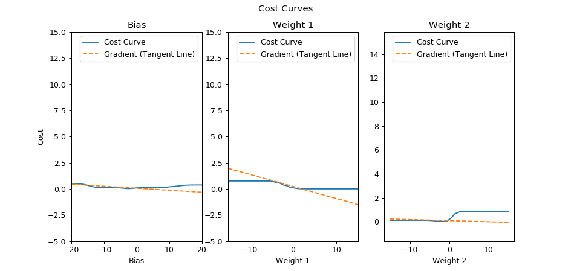

```python
def find_nearest(array, value):
    idx = (np.abs(array - value)).argmin()
    return idx

def match(array, value):
    cond = array == value
    return np.where(cond)[0]

def match_2(array1, array2, value1, value2):
    cond1 = array1 == value1
    cond2 = array2 == value2
    a = np.where(cond1)[0]
    b = np.where(cond2)[0]
    return a[np.where(np.in1d(a, b))][0]

def update(iterations, nested=0):
    # Run Iteration
    if nested:
        for i in range(nested):
            cost, dcost_dtheta, data = one_iteration(X, y)
    else:
        cost, dcost_dtheta, data = one_iteration(X, y)
    # Replot Cost Curves
    b_nearest = find_nearest(b_sim, prev_theta[0])
    w1_nearest = find_nearest(w1_raw, prev_theta[1])
    w2_nearest = find_nearest(w2_raw, prev_theta[2])
    curve_b.set_ydata(cost_sim_ce[match_2(w1_sim, w2_sim, w1_raw[w1_nearest], w2_raw[w2_nearest])])
    curve_w1.set_ydata(cost_sim_ce[match(w2_sim, w2_raw[w2_nearest]), b_nearest])
    curve_w2.set_ydata(cost_sim_ce[match(w1_sim, w1_raw[w1_nearest]), b_nearest])
    # Replot Tangents
    intercept_b = cost - (prev_theta[0] * dcost_dtheta[0])
    intercept_w1 = cost - (prev_theta[1] * dcost_dtheta[1])
    intercept_w2 = cost - (prev_theta[2] * dcost_dtheta[2])
    tangent_b.set_ydata((dcost_dtheta[0]*b_sim)+intercept_b)
    tangent_w1.set_ydata((dcost_dtheta[1]*w1_raw)+intercept_w1)
    tangent_w2.set_ydata((dcost_dtheta[2]*w2_raw)+intercept_w2)
    # Clear and Redraw
    out.clear_output()
    out.append_stdout(data)
    fig.canvas.draw()

def update_ten(iterations):
    if visualize.value:
        for i in range(10):
            update(1)
    else:
        update(1, nested=10)

def update_hundred(iterations):
    if visualize.value:
        for i in range(100):
            update(1)
    else:
        update(1, nested=100)

def update_thousand(iterations):
    if visualize.value:
        print('Not Allowed, Unselect Visualize to Proceed.')
    else:
        update(1, nested=1000)

##### Widgets #####
out = widgets.Output(layout={'border': '1px solid black'})
button_one = widgets.Button(description="1 Iteration")
button_one.on_click(update)
button_ten = widgets.Button(description="10 Iterations")
button_ten.on_click(update_ten)
button_hundred = widgets.Button(description="!!!100 Iterations!!!")
button_hundred.on_click(update_hundred)
button_thousand = widgets.Button(description="!!!Warning - 1000!!!")
button_thousand.on_click(update_thousand)
visualize = widgets.Checkbox(value=False, description='Visualize Changes', disabled=False)
hbox = widgets.HBox([button_one, button_ten, button_hundred, button_thousand, visualize])

# Initialize Random Weights & Bias
theta = np.random.uniform(-5,5,size=3)

# Run First Iteration
cost, dcost_dtheta, data = one_iteration(X, y)

b_nearest = find_nearest(b_sim, prev_theta[0])
w1_nearest = find_nearest(w1_raw, prev_theta[1])
w2_nearest = find_nearest(w2_raw, prev_theta[2])

############################
### Visualize Cost Curve ###
############################
fig = plt.figure(figsize=(10.5,5))
ax = fig.add_subplot(111)
plt.suptitle('Cost Curves')

##### Bias Subplot #####
plt.subplot(1,3,1)
plt.title('Bias')
plt.xlabel('Bias')
plt.ylabel('Cost')
# Cost Curve
curve_b, = plt.plot(b_sim, cost_sim_ce[match_2(w1_sim, w2_sim, w1_raw[w1_nearest], w2_raw[w2_nearest])], label='Cost Curve')
d1,d2,d3,d4 = plt.axis()
plt.axis([-20,20,-5,15])
# Tangent
intercept_b = cost - (prev_theta[0] * dcost_dtheta[0])
tangent_b, = plt.plot(b_sim, (dcost_dtheta[0]*b_sim)+intercept_b, label='Gradient (Tangent Line)', linestyle='--')
plt.legend();

##### Weight 1 Subplot #####
plt.subplot(1,3,2)
# plt.axis([-30.5,30.5,-1000,1000])
plt.title('Weight 1')
plt.xlabel('Weight 1')
# Cost Curve
curve_w1, = plt.plot(w1_raw, cost_sim_ce[match(w2_sim, w2_raw[w2_nearest]), b_nearest], label='Cost Curve')
d1,d2,d3,d4 = plt.axis()
plt.axis([-15,15,-5,15])
# Tangent
intercept_w1 = cost - (prev_theta[1] * dcost_dtheta[1])
tangent_w1, = plt.plot(w1_raw, (dcost_dtheta[1]*w1_raw)+intercept_w1, label='Gradient (Tangent Line)', linestyle='--')
plt.legend();

##### Weight 2 Subplot #####
plt.subplot(1,3,3)
plt.title('Weight 2')
plt.xlabel('Weight 2')
# Cost Curve
curve_w2, = plt.plot(w2_raw, cost_sim_ce[match(w1_sim, w1_raw[w1_nearest]), b_nearest], label='Cost Curve')
d1,d2,d3,d4 = plt.axis()
# plt.axis([d1,d2,-1,12])
# Tangent
intercept_w2 = cost - (prev_theta[2] * dcost_dtheta[2])
tangent_w2, = plt.plot(w2_raw, (dcost_dtheta[2]*w2_raw)+intercept_w2, label='Gradient (Tangent Line)', linestyle='--')
plt.legend();

update(1)
display(hbox)
out
```

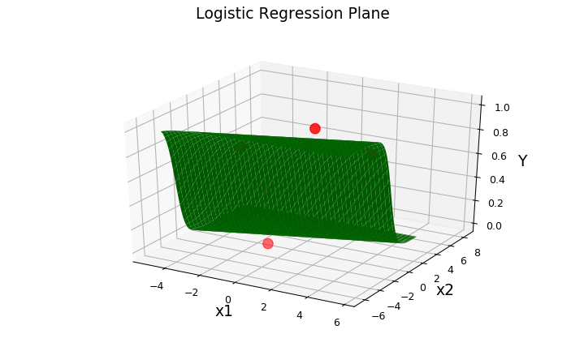

```python
def update(iterations, nested=1):
    for _ in range(nested):
        cost, dcost_dtheta, data = one_iteration(X, y)
    ax.clear()
    ax.set_xlabel('x1', fontsize=15)
    ax.set_ylabel('x2', fontsize=15)
    ax.set_zlabel('Y', fontsize=15)
    ax.scatter(x1, x2, y, s=100, c='r')
    z = model(theta[0], theta[1], lx1, theta[2], lx2)
    line = ax.plot_surface(lx1, lx2, z, color='green')
    out.clear_output()
    out.append_stdout(data)
    fig.canvas.draw()

def update_ten(iterations):
    if visualize.value:
        for i in range(10):
            update(1)
    else:
        update(1, nested=10)

def update_hundred(iterations):
    if visualize.value:
        for i in range(100):
            update(1)
    else:
        update(1, nested=100)

def update_ten_thousand(iterations):
    if visualize.value:
        print('Not Allowed, Unselect Visualize to Proceed.')
    else:
        update(1, nested=10000)

##### Widgets #####
out = widgets.Output(layout={'border': '1px solid black'})
button_one = widgets.Button(description="1 Iteration")
button_one.on_click(update)
button_ten = widgets.Button(description="10 Iterations")
button_ten.on_click(update_ten)
button_hundred = widgets.Button(description="!!!100 Iterations!!!")
button_hundred.on_click(update_hundred)
button_ten_thousand = widgets.Button(description="!!!Warning - 10000!!!")
button_ten_thousand.on_click(update_ten_thousand)
visualize = widgets.Checkbox(value=False, description='Visualize Changes', disabled=False)
hbox = widgets.HBox([button_one, button_ten, button_hundred, button_ten_thousand, visualize])

# Initialize Random Weights & Bias
theta = np.random.uniform(-5,5,size=3)

line_x_1 = np.repeat(np.linspace(-5,5,size), size)
line_x_2 = np.tile(np.linspace(-5,5,size), size)

##################################
### Visualize Regression Plane ###
##################################
fig = plt.figure(figsize=(8,5))
ax = fig.add_subplot(111, projection='3d')

plt.suptitle('Logistic Regression Plane', fontsize=15)
ax.set_xlabel('x1', fontsize=15)
ax.set_ylabel('x2', fontsize=15)
ax.set_zlabel('Y', fontsize=15)

ax.scatter(x1, x2, y, s=100, c='r')
z = model(theta[0], theta[1], lx1, theta[2], lx2)
line = ax.plot_surface(lx1, lx2, z, color='green')

update(1)
display(hbox)
out
```

Previous: Next:

Linear Regression Exercise Logistic Regression Exercise